# TCC

As plantas do bloco do 1 ficaram com os menores ranks, como podemos observar pelos boxplots abaixo:

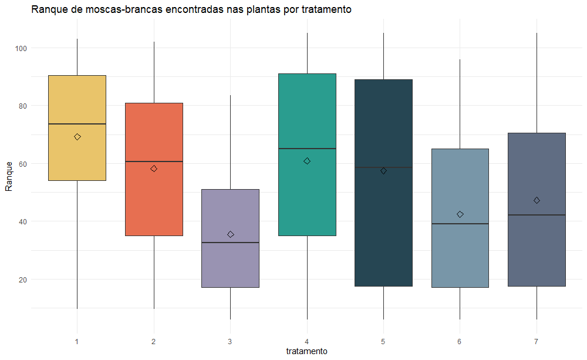

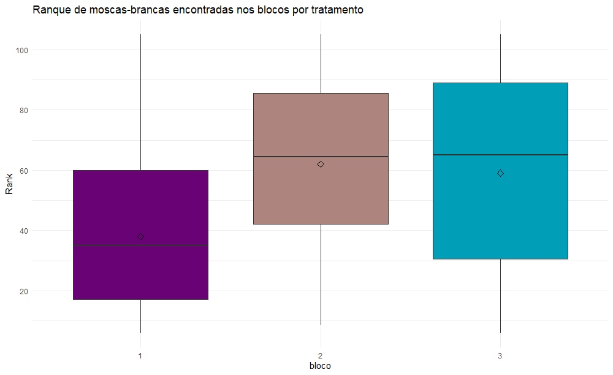

Novamente, todos os efeitos e interações são significativos, exceto pela variação semanal, que não ocorre pois os ranks sempre variam de 0 a 105. Essa característica induz os valores médios semanais a serem 53.

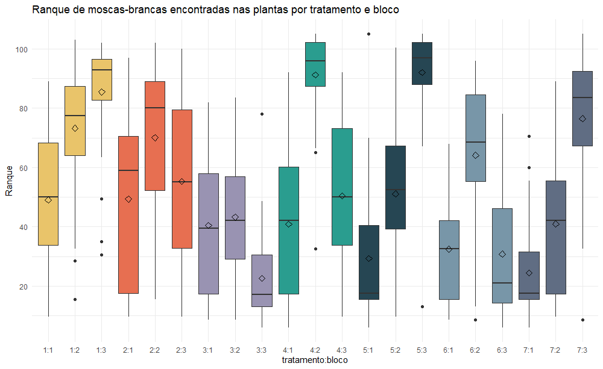

Pela linha temporal abaixo, podemos ver que os tratamentos apresentam comportamentos diferentes no decorrer do estudo. os tratamentos sem a presença da variedade selvagem crescem enquanto os tratamentos com a variedade selvagem se mantém em níveis baixos por todo o período estudado.

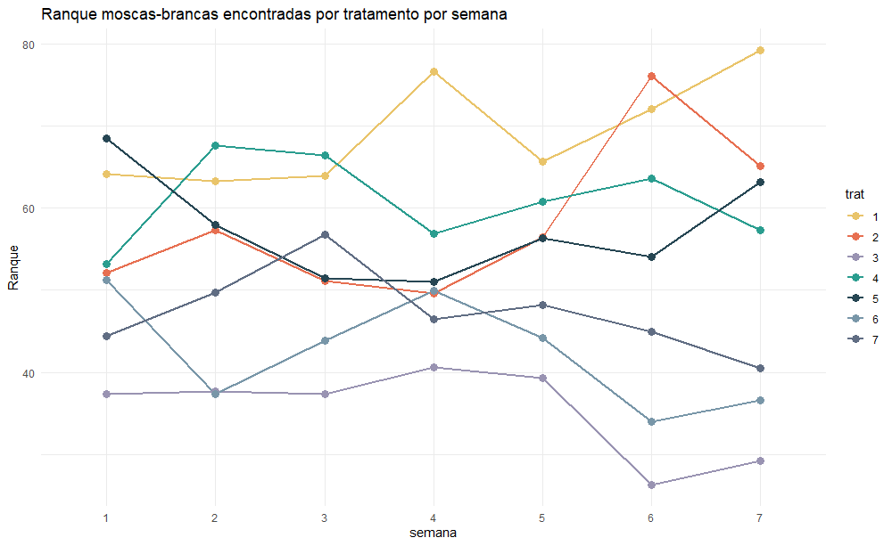

Em relação aos blocos, temos que o bloco 2 apresenta uma queda no início do estudo e se estabiliza em torno do ranque médio 60. O bloco 3 apresenta um crescimento e também estabiliza em torno do valor 60. Já o bloco 1 tem queda no ranque médio semanal e por fim uma leve alta.

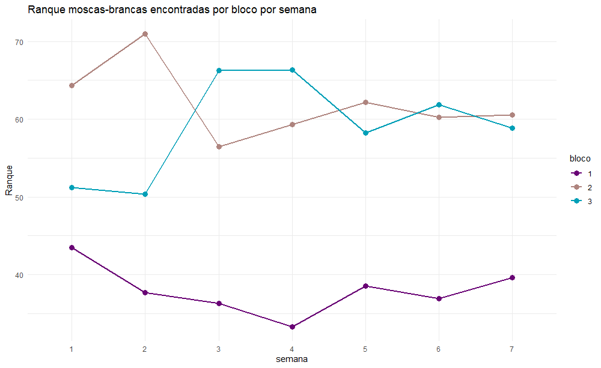

Análise de variância desconsiderando as medidas repetidas:

```r
modelo2 <- aov(rank~trat*bloco)
summary(modelo2)
shapiro.test(modelo2$residuals)#
TukeyHSD(modelo2)[1]
scottknott(plantas$rank,plantas$trat,714,338612)
```

```
##              Df Sum Sq Mean Sq F value Pr(>F)
## trat          6  86918   14486   30.55 <2e-16 ***
## bloco         2  83934   41967   88.49 <2e-16 ***
## trat:bloco   12 152493   12708   26.80 <2e-16 ***
## Residuals   714 338612     474
## ---
## Signif. codes:  0 '***' 0.001 '**' 0.01 '*' 0.05 '.' 0.1 ' ' 1
##
##  Shapiro-Wilk normality test
##
## data:  modelo2$residuals
## W = 0.99587, p-value = 0.04906
##
## $trat
##           diff        lwr         upr        p adj
## 2-1 -11.028571 -19.915250  -2.1418924 4.854436e-03
## 3-1 -33.857143 -42.743822 -24.9704639 0.000000e+00
## 4-1  -8.428571 -17.315250   0.4581076 7.608519e-02
## 5-1 -11.776190 -20.662869  -2.8895115 1.882729e-03
## 6-1 -26.842857 -35.729536 -17.9561782 0.000000e+00
## 7-1 -22.000000 -30.886679 -13.1133210 0.000000e+00
## 3-2 -22.828571 -31.715250 -13.9418924 0.000000e+00
## 4-2   2.600000  -6.286679  11.4866790 9.775182e-01
## 5-2  -0.747619  -9.634298   8.1390599 9.999804e-01
## 6-2 -15.814286 -24.700965  -6.9276067 3.921435e-06
## 7-2 -10.971429 -19.858108  -2.0847496 5.204758e-03
## 4-3  25.428571  16.541892  34.3152504 0.000000e+00
## 5-3  22.080952  13.194273  30.9676314 0.000000e+00
## 6-3   7.014286  -1.872393  15.9009647 2.293159e-01
## 7-3  11.857143   2.970464  20.7438218 1.692602e-03
## 5-4  -3.347619 -12.234298   5.5390599 9.239088e-01
## 6-4 -18.414286 -27.300965  -9.5276067 2.758044e-08
## 7-4 -13.571429 -22.458108  -4.6847496 1.496534e-04
## 6-5 -15.066667 -23.953346  -6.1799877 1.397672e-05
## 7-5 -10.223810 -19.110489  -1.3371305 1.248602e-02
## 7-6   4.842857  -4.043822  13.7295361 6.750887e-01
##
##
## Teste de Scott-Knott
## ------------------------------------------------------------------------
##   Grupos Tratamentos   Medias
## 1      a           1 69.27619
## 2      b           4 60.84762
## 3      b           2 58.24762
## 4      b           5 57.50000
## 5      c           7 47.27619
## 6      c           6 42.43333
## 7      d           3 35.41905
## ------------------------------------------------------------------------
```

Análises de variância por semana e teste subjacentes em caso de significância dos tratamentos:

```r
#Análise de variância por semanas
mod_semana1 <- aov(rank~trat*bloco,data=plantas[semana=="1",])
summary(mod_semana1)
shapiro.test(mod_semana1$residuals)
TukeyHSD(mod_semana1)
scottknott(plantas$rank[semana=="1"],plantas$trat[semana=="1"],84,48032)
```

```
##             Df Sum Sq Mean Sq F value    Pr(>F)
## trat         6  10303    1717   3.003   0.01044 *
## bloco        2   7734    3867   6.762   0.00189 **
## trat:bloco  12  28197    2350   4.109 0.0000492 ***
## Residuals   84  48032     572
## ---
## Signif. codes:  0 '***' 0.001 '**' 0.01 '*' 0.05 '.' 0.1 ' ' 1
##
##  Shapiro-Wilk normality test
##
## data:  mod_semana1$residuals
## W = 0.9799, p-value = 0.1117
##
##   Tukey multiple comparisons of means
##     95% family-wise confidence level
##
## Fit: aov(formula = rank ~ trat * bloco, data = plantas[semana == "1", ])
##
## $trat
##           diff        lwr        upr     p adj
## 2-1 -12.066667 -38.444523 14.3111900 0.8098409
## 3-1 -26.800000 -53.177857 -0.4221433 0.0439516
## 4-1 -10.933333 -37.311190 15.4445234 0.8712617
## 5-1   4.333333 -22.044523 30.7111900 0.9988438
## 6-1 -12.966667 -39.344523 13.4111900 0.7528384
## 7-1 -19.733333 -46.111190  6.6445234 0.2758055
## 3-2 -14.733333 -41.111190 11.6445234 0.6262641
## 4-2   1.133333 -25.244523 27.5111900 0.9999996
## 5-2  16.400000  -9.977857 42.7778567 0.5002796
## 6-2  -0.900000 -27.277857 25.4778567 0.9999999
## 7-2  -7.666667 -34.044523 18.7111900 0.9748980
## 4-3  15.866667 -10.511190 42.2445234 0.5404721
## 5-3  31.133333   4.755477 57.5111900 0.0103838
## 6-3  13.833333 -12.544523 40.2111900 0.6925812
## 7-3   7.066667 -19.311190 33.4445234 0.9834076
## 5-4  15.266667 -11.111190 41.6445234 0.5859912
## 6-4  -2.033333 -28.411190 24.3445234 0.9999859
## 7-4  -8.800000 -35.177857 17.5778567 0.9508714
## 6-5 -17.300000 -43.677857  9.0778567 0.4341214
## 7-5 -24.066667 -50.444523  2.3111900 0.0972524
```

[output cut: 218 more lines]

```
## 7:3-5:3  -6.1  -61.857755  49.6577553 1.0000000
## 7:3-6:3  28.7  -27.057755  84.4577553 0.9401806
##
##
## Teste de Scott-Knott
## ------------------------------------------------------------------------
##   Grupos Tratamentos   Medias
## 1      a           5 68.50000
## 2      a           1 64.16667
## 3      b           4 53.23333
## 4      b           2 52.10000
## 5      b           6 51.20000
## 6      b           7 44.43333
## 7      b           3 37.36667
## ------------------------------------------------------------------------
```

```r
mod_semana2 <- aov(rank~trat*bloco,data=plantas[semana=="2",])
summary(mod_semana2)
shapiro.test(mod_semana2$residuals)
TukeyHSD(mod_semana1)
scottknott(plantas$rank[semana=="2"],plantas$trat[semana=="2"],84,32740)
```

```
##             Df Sum Sq Mean Sq F value   Pr(>F)
## trat         6  12821    2137   5.482 7.91e-05 ***
## bloco        2  19706    9853  25.279 2.54e-09 ***
## trat:bloco  12  30383    2532   6.496 4.78e-08 ***
## Residuals   84  32740     390
## ---
## Signif. codes:  0 '***' 0.001 '**' 0.01 '*' 0.05 '.' 0.1 ' ' 1
##
##  Shapiro-Wilk normality test
##
## data:  mod_semana2$residuals
## W = 0.98098, p-value = 0.1368
##
##   Tukey multiple comparisons of means
##     95% family-wise confidence level
##
## Fit: aov(formula = rank ~ trat * bloco, data = plantas[semana == "1", ])
##
## $trat
##           diff        lwr        upr     p adj
## 2-1 -12.066667 -38.444523 14.3111900 0.8098409
## 3-1 -26.800000 -53.177857 -0.4221433 0.0439516
## 4-1 -10.933333 -37.311190 15.4445234 0.8712617
## 5-1   4.333333 -22.044523 30.7111900 0.9988438
## 6-1 -12.966667 -39.344523 13.4111900 0.7528384
## 7-1 -19.733333 -46.111190  6.6445234 0.2758055
## 3-2 -14.733333 -41.111190 11.6445234 0.6262641
## 4-2   1.133333 -25.244523 27.5111900 0.9999996
## 5-2  16.400000  -9.977857 42.7778567 0.5002796
## 6-2  -0.900000 -27.277857 25.4778567 0.9999999
## 7-2  -7.666667 -34.044523 18.7111900 0.9748980
## 4-3  15.866667 -10.511190 42.2445234 0.5404721
## 5-3  31.133333   4.755477 57.5111900 0.0103838
## 6-3  13.833333 -12.544523 40.2111900 0.6925812
## 7-3   7.066667 -19.311190 33.4445234 0.9834076
## 5-4  15.266667 -11.111190 41.6445234 0.5859912
## 6-4  -2.033333 -28.411190 24.3445234 0.9999859
## 7-4  -8.800000 -35.177857 17.5778567 0.9508714
## 6-5 -17.300000 -43.677857  9.0778567 0.4341214
## 7-5 -24.066667 -50.444523  2.3111900 0.0972524
```

[output cut: 218 more lines]

```
## 7:3-5:3  -6.1  -61.857755  49.6577553 1.0000000
## 7:3-6:3  28.7  -27.057755  84.4577553 0.9401806
##
##
## Teste de Scott-Knott
## ------------------------------------------------------------------------
##   Grupos Tratamentos   Medias
## 1      a           4 67.66667
## 2      a           1 63.26667
## 3      a           5 58.00000
## 4      a           2 57.33333
## 5      b           7 49.70000
## 6      b           3 37.70000
## 7      b           6 37.33333
## ------------------------------------------------------------------------
```

```r
mod_semana3 <- aov(rank~trat*bloco,data=plantas[semana=="3",])
summary(mod_semana3)
shapiro.test(mod_semana3$residuals)
TukeyHSD(mod_semana1)
scottknott(plantas$rank[semana=="3"],plantas$trat[semana=="3"],84,31428)
```

```
##             Df Sum Sq Mean Sq F value   Pr(>F)
## trat         6   9737    1623   4.338 0.000734 ***
## bloco        2  16387    8194  21.900 2.22e-08 ***
## trat:bloco  12  35135    2928   7.826 1.43e-09 ***
## Residuals   84  31428     374
## ---
## Signif. codes:  0 '***' 0.001 '**' 0.01 '*' 0.05 '.' 0.1 ' ' 1
##
##  Shapiro-Wilk normality test
##
## data:  mod_semana3$residuals
## W = 0.98725, p-value = 0.4185
##
##   Tukey multiple comparisons of means
##     95% family-wise confidence level
##
## Fit: aov(formula = rank ~ trat * bloco, data = plantas[semana == "1", ])
##
## $trat
##           diff        lwr        upr     p adj
## 2-1 -12.066667 -38.444523 14.3111900 0.8098409
## 3-1 -26.800000 -53.177857 -0.4221433 0.0439516
## 4-1 -10.933333 -37.311190 15.4445234 0.8712617
## 5-1   4.333333 -22.044523 30.7111900 0.9988438
## 6-1 -12.966667 -39.344523 13.4111900 0.7528384
## 7-1 -19.733333 -46.111190  6.6445234 0.2758055
## 3-2 -14.733333 -41.111190 11.6445234 0.6262641
## 4-2   1.133333 -25.244523 27.5111900 0.9999996
## 5-2  16.400000  -9.977857 42.7778567 0.5002796
## 6-2  -0.900000 -27.277857 25.4778567 0.9999999
## 7-2  -7.666667 -34.044523 18.7111900 0.9748980
## 4-3  15.866667 -10.511190 42.2445234 0.5404721
## 5-3  31.133333   4.755477 57.5111900 0.0103838
## 6-3  13.833333 -12.544523 40.2111900 0.6925812
## 7-3   7.066667 -19.311190 33.4445234 0.9834076
## 5-4  15.266667 -11.111190 41.6445234 0.5859912
## 6-4  -2.033333 -28.411190 24.3445234 0.9999859
## 7-4  -8.800000 -35.177857 17.5778567 0.9508714
## 6-5 -17.300000 -43.677857  9.0778567 0.4341214
## 7-5 -24.066667 -50.444523  2.3111900 0.0972524
```

[output cut: 218 more lines]

```
## 7:3-5:3  -6.1  -61.857755  49.6577553 1.0000000
## 7:3-6:3  28.7  -27.057755  84.4577553 0.9401806
##
##
## Teste de Scott-Knott
## ------------------------------------------------------------------------
##   Grupos Tratamentos   Medias
## 1      a           4 66.46667
## 2      a           1 63.96667
## 3      a           7 56.76667
## 4      b           5 51.46667
## 5      b           2 51.10000
## 6      b           6 43.83333
## 7      b           3 37.40000
## ------------------------------------------------------------------------
```

```r
mod_semana4 <- aov(rank~trat*bloco,data=plantas[semana=="4",])
summary(mod_semana4)
shapiro.test(mod_semana4$residuals) # trat significativo
TukeyHSD(mod_semana4)
scottknott(plantas$rank[semana=="4"],plantas$trat[semana=="4"],84,22812)
```

```
##             Df Sum Sq Mean Sq F value   Pr(>F)
## trat         6  11952    1992   7.335 2.53e-06 ***
## bloco        2  21163   10581  38.963 1.07e-12 ***
## trat:bloco  12  37331    3111  11.455 3.15e-13 ***
## Residuals   84  22812     272
## ---
## Signif. codes:  0 '***' 0.001 '**' 0.01 '*' 0.05 '.' 0.1 ' ' 1
##
##  Shapiro-Wilk normality test
##
## data:  mod_semana4$residuals
## W = 0.98149, p-value = 0.1504
##
##   Tukey multiple comparisons of means
##     95% family-wise confidence level
##
## Fit: aov(formula = rank ~ trat * bloco, data = plantas[semana == "4", ])
##
## $trat
##            diff        lwr        upr     p adj
## 2-1 -27.0666667 -45.245232  -8.888101 0.0004246
## 3-1 -36.0666667 -54.245232 -17.888101 0.0000010
## 4-1 -19.7333333 -37.911899  -1.554768 0.0244864
## 5-1 -25.6666667 -43.845232  -7.488101 0.0009914
## 6-1 -26.7000000 -44.878566  -8.521434 0.0005317
## 7-1 -30.2000000 -48.378566 -12.021434 0.0000576
## 3-2  -9.0000000 -27.178566   9.178566 0.7466155
## 4-2   7.3333333 -10.845232  25.511899 0.8850041
## 5-2   1.4000000 -16.778566  19.578566 0.9999860
## 6-2   0.3666667 -17.811899  18.545232 1.0000000
## 7-2  -3.1333333 -21.311899  15.045232 0.9984832
## 4-3  16.3333333  -1.845232  34.511899 0.1073568
## 5-3  10.4000000  -7.778566  28.578566 0.5993111
## 6-3   9.3666667  -8.811899  27.545232 0.7098351
## 7-3   5.8666667 -12.311899  24.045232 0.9580490
## 5-4  -5.9333333 -24.111899  12.245232 0.9557187
## 6-4  -6.9666667 -25.145232  11.211899 0.9076960
## 7-4 -10.4666667 -28.645232   7.711899 0.5919866
## 6-5  -1.0333333 -19.211899  17.145232 0.9999977
## 7-5  -4.5333333 -22.711899  13.645232 0.9885717
```

[output cut: 218 more lines]

```
## 7:3-5:3 -1.260000e+01  -51.02601849  25.826018 0.9997157
## 7:3-6:3  4.740000e+01    8.97398151  85.826018 0.0030206
##
##
## Teste de Scott-Knott
## ------------------------------------------------------------------------
##   Grupos Tratamentos   Medias
## 1      a           1 76.63333
## 2      b           4 56.90000
## 3      b           5 50.96667
## 4      b           6 49.93333
## 5      b           2 49.56667
## 6      b           7 46.43333
## 7      b           3 40.56667
## ------------------------------------------------------------------------
```

```r
mod_semana5 <- aov(rank~trat*bloco,data=plantas[semana=="5",])
summary(mod_semana5)
shapiro.test(mod_semana5$residuals)
TukeyHSD(mod_semana4)
scottknott(plantas$rank[semana=="5"],plantas$trat[semana=="5"],84,41491)
```

```
##             Df Sum Sq Mean Sq F value      Pr(>F)
## trat         6   7984    1331   2.694      0.0193 *
## bloco        2  11221    5611  11.359 0.000043022 ***
## trat:bloco  12  33213    2768   5.603 0.000000582 ***
## Residuals   84  41491     494
## ---
## Signif. codes:  0 '***' 0.001 '**' 0.01 '*' 0.05 '.' 0.1 ' ' 1
##
##  Shapiro-Wilk normality test
##
## data:  mod_semana5$residuals
## W = 0.97888, p-value = 0.09214
##
##   Tukey multiple comparisons of means
##     95% family-wise confidence level
##
## Fit: aov(formula = rank ~ trat * bloco, data = plantas[semana == "4", ])
##
## $trat
##            diff        lwr        upr     p adj
## 2-1 -27.0666667 -45.245232  -8.888101 0.0004246
## 3-1 -36.0666667 -54.245232 -17.888101 0.0000010
## 4-1 -19.7333333 -37.911899  -1.554768 0.0244864
## 5-1 -25.6666667 -43.845232  -7.488101 0.0009914
## 6-1 -26.7000000 -44.878566  -8.521434 0.0005317
## 7-1 -30.2000000 -48.378566 -12.021434 0.0000576
## 3-2  -9.0000000 -27.178566   9.178566 0.7466155
## 4-2   7.3333333 -10.845232  25.511899 0.8850041
## 5-2   1.4000000 -16.778566  19.578566 0.9999860
## 6-2   0.3666667 -17.811899  18.545232 1.0000000
## 7-2  -3.1333333 -21.311899  15.045232 0.9984832
## 4-3  16.3333333  -1.845232  34.511899 0.1073568
## 5-3  10.4000000  -7.778566  28.578566 0.5993111
## 6-3   9.3666667  -8.811899  27.545232 0.7098351
## 7-3   5.8666667 -12.311899  24.045232 0.9580490
## 5-4  -5.9333333 -24.111899  12.245232 0.9557187
## 6-4  -6.9666667 -25.145232  11.211899 0.9076960
## 7-4 -10.4666667 -28.645232   7.711899 0.5919866
## 6-5  -1.0333333 -19.211899  17.145232 0.9999977
## 7-5  -4.5333333 -22.711899  13.645232 0.9885717
```

[output cut: 218 more lines]

```
## 7:3-5:3 -1.260000e+01  -51.02601849  25.826018 0.9997157
## 7:3-6:3  4.740000e+01    8.97398151  85.826018 0.0030206
##
##
## Teste de Scott-Knott
## ------------------------------------------------------------------------
##   Grupos Tratamentos   Medias
## 1      a           1 65.70000
## 2      a           4 60.76667
## 3      a           2 56.43333
## 4      a           5 56.36667
## 5      b           7 48.23333
## 6      b           6 44.16667
## 7      b           3 39.33333
## ------------------------------------------------------------------------
```

```r
mod_semana6 <- aov(rank~trat*bloco,data=plantas[semana=="6",])
summary(mod_semana6)
shapiro.test(mod_semana6$residuals)
TukeyHSD(mod_semana6)
scottknott(plantas$rank[semana=="6"],plantas$trat[semana=="6"],84,30986)
```

```
##             Df Sum Sq Mean Sq F value   Pr(>F)
## trat         6  32225    5371  14.560 2.54e-11 ***
## bloco        2  13632    6816  18.478 2.24e-07 ***
## trat:bloco  12  19156    1596   4.328 2.53e-05 ***
## Residuals   84  30986     369
## ---
## Signif. codes:  0 '***' 0.001 '**' 0.01 '*' 0.05 '.' 0.1 ' ' 1
##
##  Shapiro-Wilk normality test
##
## data:  mod_semana6$residuals
## W = 0.97144, p-value = 0.02283
##
##   Tukey multiple comparisons of means
##     95% family-wise confidence level
##
## Fit: aov(formula = rank ~ trat * bloco, data = plantas[semana == "6", ])
##
## $trat
##           diff        lwr         upr     p adj
## 2-1   4.066667 -17.119766  25.2530991 0.9972306
## 3-1 -45.700000 -66.886432 -24.5135676 0.0000001
## 4-1  -8.433333 -29.619766  12.7530991 0.8913180
## 5-1 -17.966667 -39.153099   3.2197657 0.1513029
## 6-1 -38.066667 -59.253099 -16.8802343 0.0000110
## 7-1 -27.133333 -48.319766  -5.9469009 0.0039061
## 3-2 -49.766667 -70.953099 -28.5802343 0.0000000
## 4-2 -12.500000 -33.686432   8.6864324 0.5635077
## 5-2 -22.033333 -43.219766  -0.8469009 0.0360857
## 6-2 -42.133333 -63.319766 -20.9469009 0.0000010
## 7-2 -31.200000 -52.386432 -10.0135676 0.0005092
## 4-3  37.266667  16.080234  58.4530991 0.0000176
## 5-3  27.733333   6.546901  48.9197657 0.0029304
## 6-3   7.633333 -13.553099  28.8197657 0.9298569
## 7-3  18.566667  -2.619766  39.7530991 0.1251966
## 5-4  -9.533333 -30.719766  11.6530991 0.8214226
## 6-4 -29.633333 -50.819766  -8.4469009 0.0011434
## 7-4 -18.700000 -39.886432   2.4864324 0.1199046
## 6-5 -20.100000 -41.286432   1.0864324 0.0744363
## 7-5  -9.166667 -30.353099  12.0197657 0.8468142
```

[output cut: 218 more lines]

```
## 7:3-5:3 -34.7  -79.484075  10.084075 0.3576008
## 7:3-6:3  40.2   -4.584075  84.984075 0.1366023
##
##
## Teste de Scott-Knott
## ------------------------------------------------------------------------
##   Grupos Tratamentos   Medias
## 1      a           2 76.10000
## 2      a           1 72.03333
## 3      b           4 63.60000
## 4      b           5 54.06667
## 5      c           7 44.90000
## 6      d           6 33.96667
## 7      d           3 26.33333
## ------------------------------------------------------------------------
```

```r
mod_semana7 <- aov(rank~trat*bloco,data=plantas[semana=="7",])
summary(mod_semana7)
shapiro.test(mod_semana7$residuals)
TukeyHSD(mod_semana6)
scottknott(plantas$rank[semana=="7"],plantas$trat[semana=="7"],84,33513)
```

```
##             Df Sum Sq Mean Sq F value   Pr(>F)
## trat         6  29148    4858  12.176 8.31e-10 ***
## bloco        2   9457    4729  11.852 2.92e-05 ***
## trat:bloco  12  24071    2006   5.028 3.10e-06 ***
## Residuals   84  33513     399
## ---
## Signif. codes:  0 '***' 0.001 '**' 0.01 '*' 0.05 '.' 0.1 ' ' 1
##
##  Shapiro-Wilk normality test
##
## data:  mod_semana7$residuals
## W = 0.9836, p-value = 0.2222
##
##   Tukey multiple comparisons of means
##     95% family-wise confidence level
##
## Fit: aov(formula = rank ~ trat * bloco, data = plantas[semana == "6", ])
##
## $trat
##           diff        lwr         upr     p adj
## 2-1   4.066667 -17.119766  25.2530991 0.9972306
## 3-1 -45.700000 -66.886432 -24.5135676 0.0000001
## 4-1  -8.433333 -29.619766  12.7530991 0.8913180
## 5-1 -17.966667 -39.153099   3.2197657 0.1513029
## 6-1 -38.066667 -59.253099 -16.8802343 0.0000110
## 7-1 -27.133333 -48.319766  -5.9469009 0.0039061
## 3-2 -49.766667 -70.953099 -28.5802343 0.0000000
## 4-2 -12.500000 -33.686432   8.6864324 0.5635077
## 5-2 -22.033333 -43.219766  -0.8469009 0.0360857
## 6-2 -42.133333 -63.319766 -20.9469009 0.0000010
## 7-2 -31.200000 -52.386432 -10.0135676 0.0005092
## 4-3  37.266667  16.080234  58.4530991 0.0000176
## 5-3  27.733333   6.546901  48.9197657 0.0029304
## 6-3   7.633333 -13.553099  28.8197657 0.9298569
## 7-3  18.566667  -2.619766  39.7530991 0.1251966
## 5-4  -9.533333 -30.719766  11.6530991 0.8214226
## 6-4 -29.633333 -50.819766  -8.4469009 0.0011434
## 7-4 -18.700000 -39.886432   2.4864324 0.1199046
## 6-5 -20.100000 -41.286432   1.0864324 0.0744363
## 7-5  -9.166667 -30.353099  12.0197657 0.8468142
```

[output cut: 218 more lines]

```
## 7:3-5:3 -34.7  -79.484075  10.084075 0.3576008
## 7:3-6:3  40.2   -4.584075  84.984075 0.1366023
##
##
## Teste de Scott-Knott
## ------------------------------------------------------------------------
##   Grupos Tratamentos   Medias
## 1      a           1 79.16667
## 2      b           2 65.10000
## 3      b           5 63.13333
## 4      b           4 57.30000
## 5      c           7 40.46667
## 6      c           6 36.60000
## 7      c           3 29.23333
## ------------------------------------------------------------------------
```

#### Colheita

```r
colheita <- read.xlsx("/cloud/project/Colheita.xlsx")
colheita$bloco <- factor(colheita$bloco)
colheita$trat <- factor(colheita$trat)
colheita$planta <- factor(colheita$planta)
attach(colheita)
```

Na última parte do estudo, fiz uma regressão de Poisson pra os dados de colheita.

A média estimada de frutos por planta é 6,81 e a variância é 6,42. Assim, não há o problema de superdispersão.

De qualquer forma, optei por testar modelos de Poisson e Binomial Negativa. O melhor modelo, pelo critério AIC considerando as variáveis explicativas tratamento, bloco e interação trat:bloco, foi o modelo apenas com intercepto e função de ligação logaritmo.

```r
mean(frutos)
```

```
## [1] 6.816667
```

```r
var(frutos)
```

```
## [1] 6.423446
```